# 重賞レース予測レポート【毎時自動更新中】

作成日時: 2026/10/10 10:05:50

☞ [マニュアル(pdf)](https://ryutoro-galois.github.io/keiba-predictor/manual/manual.pdf)

☞ 過去6年の同一レース結果: [2025年](https://ryutoro-galois.github.io/keiba-predictor/report/PredResult_2025y_raceDate_20251011_20251013.html), [2024年](https://ryutoro-galois.github.io/keiba-predictor/report/PredResult_2024y_raceDate_20241005_20241006.html), [2023年](https://ryutoro-galois.github.io/keiba-predictor/report/PredResult_2023y_raceDate_20231007_20231009.html), [2022年](https://ryutoro-galois.github.io/keiba-predictor/report/PredResult_2022y_raceDate_20221008_20221010.html), [2021年](https://ryutoro-galois.github.io/keiba-predictor/report/PredResult_2021y_raceDate_20211009_20211010.html), [2020年](https://ryutoro-galois.github.io/keiba-predictor/report/PredResult_2020y_raceDate_20201010_20201011.html)

☞ 過去4週間の別レース結果: [1週前(10/4)](https://ryutoro-galois.github.io/keiba-predictor/report/PredResult_2026y_raceDate_20261004_20261004.html), [2週前(9/26-27)](https://ryutoro-galois.github.io/keiba-predictor/report/PredResult_2026y_raceDate_20260926_20260927.html), [3週前(9/19-21)](https://ryutoro-galois.github.io/keiba-predictor/report/PredResult_2026y_raceDate_20260919_20260921.html), [4週前(9/12-13)](https://ryutoro-galois.github.io/keiba-predictor/report/PredResult_2026y_raceDate_20260912_20260913.html)

☞ netkeiba: [サウジアラビアロイヤルカップ(GⅢ)](https://race.netkeiba.com/race/shutuba.html?race_id=202605040311&rf=race_list), [アイルランドトロフィー(GⅡ)](https://race.netkeiba.com/race/shutuba.html?race_id=202605040411&rf=race_list), [スワンステークス(GⅡ)](https://race.netkeiba.com/race/shutuba.html?race_id=202608040511&rf=race_list)

## 0. 推し馬予測 (AI予測)

### 【サウジアラビアRC(GⅢ) 2026/10/10(土)】

- 本命(◎): 1-3着内確率(勝負強さ)が1位の馬
- 対抗(◯): 1-3着内確率が2-N位(20%程度以上)の中で予測タイムが最も速い馬
- 3番手(▲): 1-3着内確率が2-N位(20%程度以上)のでダークホース確率が最も高い馬
- 穴: ダークホース確率が上位1-M位(40%程度以上)の中で1-3着内確率が最も高い馬

| 推し馬 | 枠番 | 馬番 | 人気 | オッズ | 馬名 | 騎手 | 調教師 | 予測タイム(sec) | 1_順位 | 1-3着内確率(%) | 2_順位 | ﾀﾞｰｸﾎｰｽ確率(%) | 3_順位 |
| --- | --- | --- | --- | --- | --- | --- | --- | --- | --- | --- | --- | --- | --- |
| 本命(◎) | 5 | 5 | 1 | 2.5 | フィリオソラーレ | Ｃ．ルメール | 木村哲也 | 92.7 | 1 | 35.3 | 1 | 0.4 | 11 |
| 対抗(◯) | 7 | 9 | 4 | 7.8 | ジップスパーク | 田辺裕信 | 中舘英二 | 96.2 | 3 | 23.0 | 5 | 1.1 | 8 |
| 3番手(▲) | 1 | 1 | 9 | 19.9 | ギブリ | 横山典弘 | 松永幹夫 | 100.5 | 7 | 29.2 | 3 | 55.0 | 1 |
| 穴 | 6 | 7 | 11 | 61.9 | ニシノトラノスケ | 菊沢一樹 | 千葉直人 | 96.7 | 4 | 12.1 | 6 | 43.6 | 2 |

### 【アイルランドトロフィー(GⅡ) 2026/10/11(日)】

- 本命(◎): 1-3着内確率(勝負強さ)が1位の馬
- 対抗(◯): 1-3着内確率が2-N位(20%程度以上)の中で予測タイムが最も速い馬
- 3番手(▲): 1-3着内確率が2-N位(20%程度以上)のでダークホース確率が最も高い馬
- 穴: ダークホース確率が上位1-M位(40%程度以上)の中で1-3着内確率が最も高い馬

| 推し馬 | 枠番 | 馬番 | 人気 | オッズ | 馬名 | 騎手 | 調教師 | 予測タイム(sec) | 1_順位 | 1-3着内確率(%) | 2_順位 | ﾀﾞｰｸﾎｰｽ確率(%) | 3_順位 |
| --- | --- | --- | --- | --- | --- | --- | --- | --- | --- | --- | --- | --- | --- |
| 本命(◎) | 2 | 3 | 2 | 5.6 | クイーンズウォーク | 西村淳也 | 中内田充正 | 109.2 | 8 | 37.0 | 1 | 0.6 | 16 |
| 対抗(◯) | 8 | 15 | 5 | 7.2 | ジョスラン | Ｃ．ルメール | 鹿戸雄一 | 108.5 | 4 | 25.7 | 3 | 1.0 | 11 |
| 3番手(▲) | 1 | 1 | 4 | 6.9 | ニシノティアモ | 津村明秀 | 上原佑紀 | 110.7 | 9 | 28.7 | 2 | 1.0 | 13 |
| 穴 | 2 | 4 | 16 | 112.2 | クランフォード | 菊沢一樹 | 杉山晴紀 | 118.0 | 15 | 13.0 | 7 | 53.5 | 1 |

## 1. 予測チャート (タイム/勝負強さ)

### 【サウジアラビアRC(GⅢ)】

2026/10/10(土), 05_東京, 芝左1600m

[interactive chart not shown]

### 【アイルランドトロフィー(GⅡ)】

2026/10/11(日), 05_東京, 芝1800m

[interactive chart not shown]

## 2. オッズモニタリング (毎時)

### 【サウジアラビアロイヤルカップ】

[interactive chart not shown]

### 【アイルランドトロフィー】

[interactive chart not shown]

## 3. 出馬表

### 【サウジアラビアRカップ 2026/10/10(土) 】

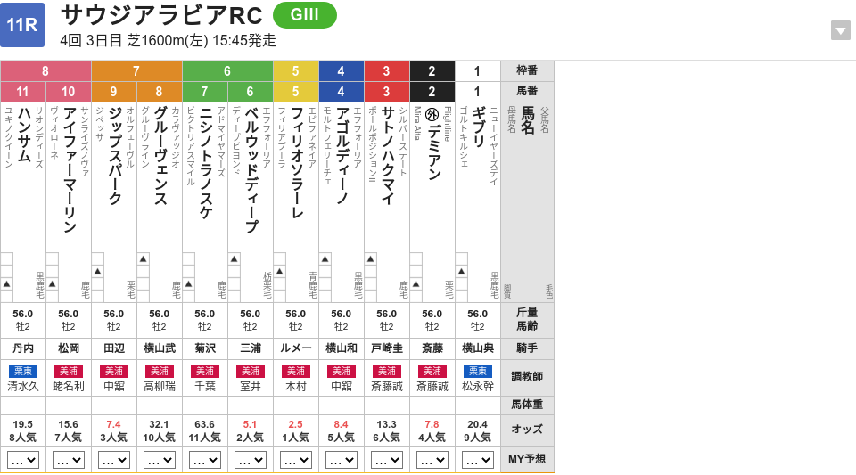

### 【サウジアラビアロイヤルカップ 2026/10/10(土) 】

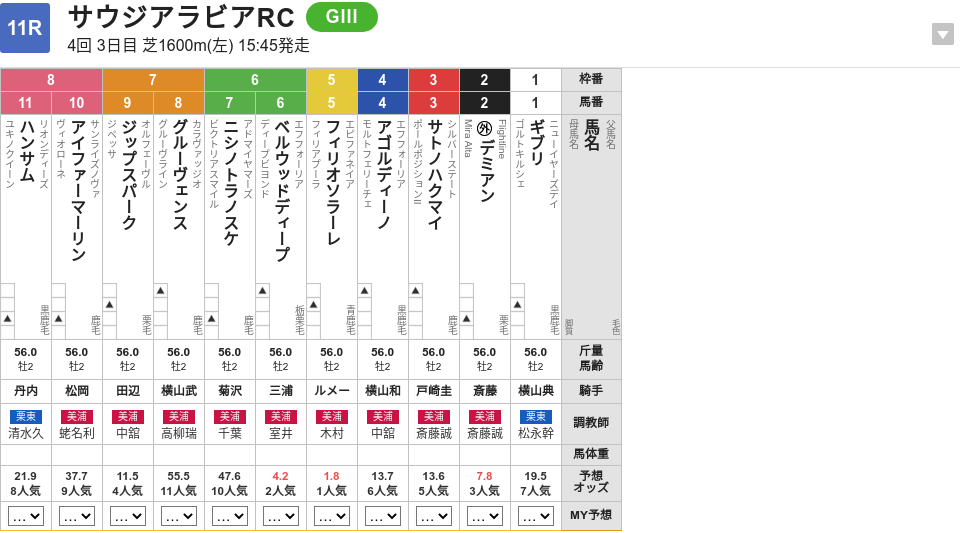

### 【アイルランドトロフィー 2026/10/11(日) 】

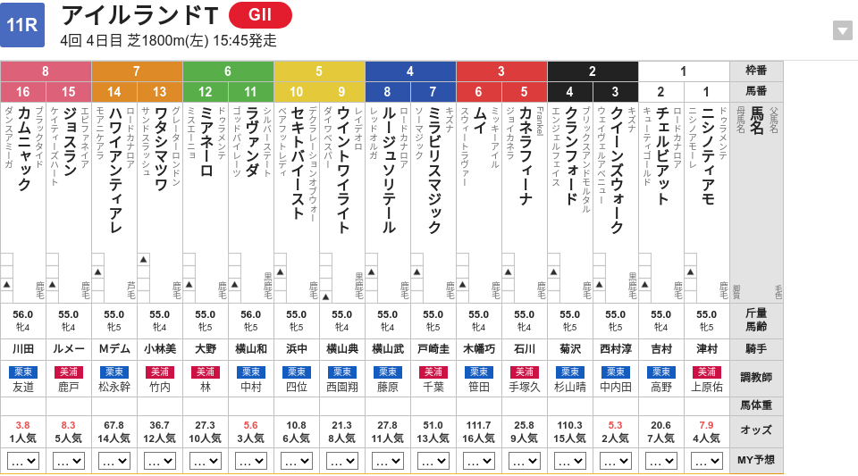

### 【スワンステークス 2026/10/12(月) 】

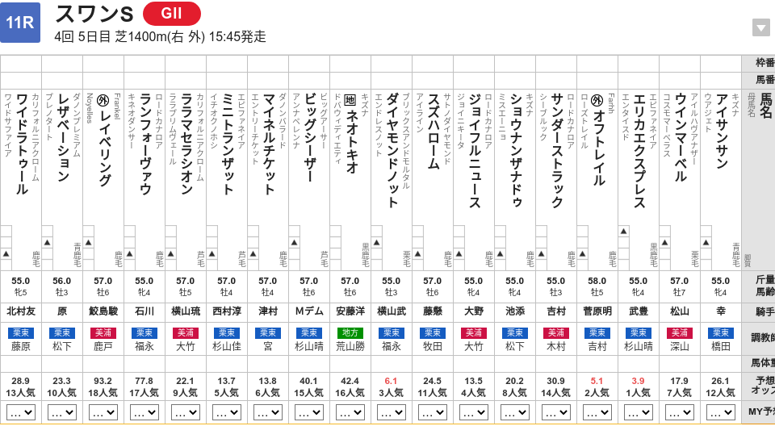

## 4. 単勝予測結果

### 【サウジアラビアRC(GⅢ) 2026/10/10(土)】

| 枠番 | 馬番 | 人気 | オッズ | 馬名 | 騎手 | 調教師 | 予測タイム(sec) | 1_順位 | 1-3着内確率(%) | 2_順位 | ﾀﾞｰｸﾎｰｽ確率(%) | 3_順位 |
| --- | --- | --- | --- | --- | --- | --- | --- | --- | --- | --- | --- | --- |
| 1 | 1 | 9 | 19.9 | ギブリ | 横山典弘 | 松永幹夫 | 100.5 | 7 | 29.2 | 3 | 55.0 | 1 |
| 2 | 2 | 3 | 7.7 | デミアン | 斎藤新 | 斎藤誠 | 97.0 | 5 | 26.2 | 4 | 1.3 | 6 |
| 3 | 3 | 6 | 13.3 | サトノハクマイ | 戸崎圭太 | 斎藤誠 | 96.0 | 2 | 11.7 | 7 | 1.2 | 7 |
| 4 | 4 | 5 | 8.4 | アゴルディーノ | 横山和生 | 中舘英二 | 104.2 | 9 | 10.3 | 8 | 1.1 | 9 |
| 5 | 5 | 1 | 2.5 | フィリオソラーレ | Ｃ．ルメール | 木村哲也 | 92.7 | 1 | 35.3 | 1 | 0.4 | 11 |
| 6 | 6 | 2 | 4.9 | ベルウッドディープ | 三浦皇成 | 室井潔 | 97.0 | 6 | 34.5 | 2 | 0.9 | 10 |
| 6 | 7 | 11 | 61.9 | ニシノトラノスケ | 菊沢一樹 | 千葉直人 | 96.7 | 4 | 12.1 | 6 | 43.6 | 2 |
| 7 | 8 | 10 | 31.6 | グルーヴェンス | 横山武史 | 高柳瑞樹 | 104.7 | 10 | 3.5 | 10 | 21.1 | 3 |
| 7 | 9 | 4 | 7.8 | ジップスパーク | 田辺裕信 | 中舘英二 | 96.2 | 3 | 23.0 | 5 | 1.1 | 8 |
| 8 | 10 | 7 | 16.7 | アイファーマーリン | 松岡正海 | 蛯名利弘 | 104.7 | 11 | 2.9 | 11 | 20.6 | 4 |

[output cut: 1 more lines]

### 【アイルランドトロフィー(GⅡ) 2026/10/11(日)】

| 枠番 | 馬番 | 人気 | オッズ | 馬名 | 騎手 | 調教師 | 予測タイム(sec) | 1_順位 | 1-3着内確率(%) | 2_順位 | ﾀﾞｰｸﾎｰｽ確率(%) | 3_順位 |
| --- | --- | --- | --- | --- | --- | --- | --- | --- | --- | --- | --- | --- |
| 1 | 1 | 4 | 6.9 | ニシノティアモ | 津村明秀 | 上原佑紀 | 110.7 | 9 | 28.7 | 2 | 1.0 | 13 |
| 1 | 2 | 7 | 17.9 | チェルビアット | 吉村誠之助 | 高野友和 | 108.5 | 3 | 14.3 | 5 | 1.4 | 9 |
| 2 | 3 | 2 | 5.6 | クイーンズウォーク | 西村淳也 | 中内田充正 | 109.2 | 8 | 37.0 | 1 | 0.6 | 16 |
| 2 | 4 | 16 | 112.2 | クランフォード | 菊沢一樹 | 杉山晴紀 | 118.0 | 15 | 13.0 | 7 | 53.5 | 1 |
| 3 | 5 | 11 | 27.0 | カネラフィーナ | 石川裕紀人 | 手塚貴久 | 108.6 | 5 | 13.5 | 6 | 36.9 | 4 |
| 3 | 6 | 15 | 104.4 | ムイ | 木幡巧也 | 笹田和秀 | 108.4 | 2 | 11.2 | 9 | 47.1 | 2 |
| 4 | 7 | 13 | 45.2 | ミラビリスマジック | 戸崎圭太 | 千葉直人 | 110.8 | 10 | 10.1 | 11 | 37.8 | 3 |
| 4 | 8 | 10 | 25.5 | ルージュソリテール | 横山武史 | 藤原英昭 | 108.6 | 7 | 10.2 | 10 | 31.8 | 5 |
| 5 | 9 | 8 | 21.1 | ウイントワイライト | 横山典弘 | 西園翔太 | 108.6 | 6 | 9.3 | 13 | 1.3 | 10 |
| 5 | 10 | 6 | 9.5 | セキトバイースト | 浜中俊 | 四位洋文 | 117.5 | 13 | 9.6 | 12 | 1.0 | 12 |

[output cut: 6 more lines]

## 5. 人気と着順の乖離率推移

### 【サウジアラビアRC_2016y_2019y】

[interactive chart not shown]

### 【サウジアラビアRC_2016y_2019y】

| No | 開催年 | 不整合率(%) | 頭数 | 人気別着順(1-3位) | 人気別着順(全体) |
| --- | --- | --- | --- | --- | --- |
| 4 | 2019 | 8.8 | 9頭 | 1-2-3 | 1\|2\|3\|6\|5\|7\|9\|4\|8 |
| 3 | 2018 | 35.2 | 8頭 | 1-7-4 | 1\|7\|4\|3\|2\|8\|5\|6 |
| 2 | 2017 | 22.5 | 18頭 | 2-1-6 | 2\|1\|6\|3\|5\|4\|9\|7\|12\|11\|13\|16\|14\|15\|10\|17\|8\|18 |
| 1 | 2016 | 53.1 | 9頭 | 3-2-1 | 3\|2\|1\|6\|5\|8\|4\|7\|9 |

## 6. 1-3番人気馬の着順分類予測

### 【サウジアラビアRC】

| 分類 | 凡例 | 発生確率(%) | 当該レース | 当該レースランク | 直近1年間 |
| --- | --- | --- | --- | --- | --- |
| 1: 1番人気のみ (1_pop1) | 1 \| * \| * | 17.8 | 1.96 | 1.96 | 0.00 |
| 4: 1,2番人気のみ (4_pop12) | 1 \| 2 \| * | 17.8 | 1.96 | 1.96 | 0.36 |
| 8: 1,2,3番人気すべて着外 (8_darkhorse) | * \| * \| * | 13.8 | 0.00 | 0.00 | 0.00 |
| 5: 1,3番人気のみ (5_pop13) | 1 \| 3 \| * | 13.2 | 0.00 | 0.00 | 0.00 |
| 7: 1,2,3番人気すべて着内 (7_pop123) | 1 \| 2 \| 3 | 10.0 | 0.12 | 0.12 | 0.20 |
| 6: 2,3番人気のみ (6_pop23) | 2 \| 3 \| * | 9.8 | 0.00 | 0.00 | 0.00 |
| 2: 2番人気のみ (2_pop2) | 2 \| * \| * | 9.3 | 0.00 | 0.00 | 0.00 |
| 3: 3番人気のみ (3_pop3) | 3 \| * \| * | 8.2 | 0.00 | 0.00 | 0.00 |

## 7. 3連複予測結果

### 【サウジアラビアRC(GⅢ) 2026/10/10(土)】

| 分類 | 馬番 | 枠番 | 人気 | 平均予測タイム(sec) | 1-3着内確率(%) | ﾀﾞｰｸﾎｰｽ確率(%) | 馬名 | 騎手 | 調教師 |
| --- | --- | --- | --- | --- | --- | --- | --- | --- | --- |
| 4: 1,2番人気のみ (4_pop12) | 5-6-1 | 5-6-1 | 1-2-9 | 96.73 | 3.56 | 0.00 | フィリオソラーレ \| ベルウッドディープ \| ギブリ | Ｃ．ルメール \| 三浦皇成 \| 横山典弘 | 木村哲也 \| 室井潔 \| 松永幹夫 |
| 7: 1,2,3番人気すべて着内 (7_pop123) | 5-6-2 | 5-6-2 | 1-2-3 | 95.57 | 3.19 | 0.00 | フィリオソラーレ \| ベルウッドディープ \| デミアン | Ｃ．ルメール \| 三浦皇成 \| 斎藤新 | 木村哲也 \| 室井潔 \| 斎藤誠 |
| 4: 1,2番人気のみ (4_pop12) | 5-6-9 | 5-6-7 | 1-2-4 | 95.30 | 2.80 | 0.00 | フィリオソラーレ \| ベルウッドディープ \| ジップスパーク | Ｃ．ルメール \| 三浦皇成 \| 田辺裕信 | 木村哲也 \| 室井潔 \| 中舘英二 |
| 5: 1,3番人気のみ (5_pop13) | 5-2-1 | 5-2-1 | 1-3-9 | 96.73 | 2.70 | 0.00 | フィリオソラーレ \| デミアン \| ギブリ | Ｃ．ルメール \| 斎藤新 \| 横山典弘 | 木村哲也 \| 斎藤誠 \| 松永幹夫 |
| 6: 2,3番人気のみ (6_pop23) | 6-2-1 | 6-2-1 | 2-3-9 | 98.17 | 2.64 | 0.01 | ベルウッドディープ \| デミアン \| ギブリ | 三浦皇成 \| 斎藤新 \| 横山典弘 | 室井潔 \| 斎藤誠 \| 松永幹夫 |
| 1: 1番人気のみ (1_pop1) | 5-9-1 | 5-7-1 | 1-4-9 | 96.47 | 2.37 | 0.00 | フィリオソラーレ \| ジップスパーク \| ギブリ | Ｃ．ルメール \| 田辺裕信 \| 横山典弘 | 木村哲也 \| 中舘英二 \| 松永幹夫 |
| 2: 2番人気のみ (2_pop2) | 6-9-1 | 6-7-1 | 2-4-9 | 97.90 | 2.32 | 0.01 | ベルウッドディープ \| ジップスパーク \| ギブリ | 三浦皇成 \| 田辺裕信 \| 横山典弘 | 室井潔 \| 中舘英二 \| 松永幹夫 |
| 5: 1,3番人気のみ (5_pop13) | 5-2-9 | 5-2-7 | 1-3-4 | 95.30 | 2.13 | 0.00 | フィリオソラーレ \| デミアン \| ジップスパーク | Ｃ．ルメール \| 斎藤新 \| 田辺裕信 | 木村哲也 \| 斎藤誠 \| 中舘英二 |
| 6: 2,3番人気のみ (6_pop23) | 6-2-9 | 6-2-7 | 2-3-4 | 96.73 | 2.08 | 0.00 | ベルウッドディープ \| デミアン \| ジップスパーク | 三浦皇成 \| 斎藤新 \| 田辺裕信 | 室井潔 \| 斎藤誠 \| 中舘英二 |
| 3: 3番人気のみ (3_pop3) | 2-9-1 | 2-7-1 | 3-4-9 | 97.90 | 1.76 | 0.01 | デミアン \| ジップスパーク \| ギブリ | 斎藤新 \| 田辺裕信 \| 横山典弘 | 斎藤誠 \| 中舘英二 \| 松永幹夫 |

[output cut: 155 more lines]

### 【アイルランドトロフィー(GⅡ) 2026/10/11(日)】

| 分類 | 馬番 | 枠番 | 人気 | 平均予測タイム(sec) | 1-3着内確率(%) | ﾀﾞｰｸﾎｰｽ確率(%) | 馬名 | 騎手 | 調教師 |
| --- | --- | --- | --- | --- | --- | --- | --- | --- | --- |
| 2: 2番人気のみ (2_pop2) | 3-1-15 | 2-1-8 | 2-4-5 | 109.47 | 2.73 | 0.00 | クイーンズウォーク \| ニシノティアモ \| ジョスラン | 西村淳也 \| 津村明秀 \| Ｃ．ルメール | 中内田充正 \| 上原佑紀 \| 鹿戸雄一 |
| 6: 2,3番人気のみ (6_pop23) | 3-11-1 | 2-6-1 | 2-3-4 | 112.87 | 1.78 | 0.00 | クイーンズウォーク \| ラヴァンダ \| ニシノティアモ | 西村淳也 \| 横山和生 \| 津村明秀 | 中内田充正 \| 中村直也 \| 上原佑紀 |
| 6: 2,3番人気のみ (6_pop23) | 3-11-15 | 2-6-8 | 2-3-5 | 112.13 | 1.59 | 0.00 | クイーンズウォーク \| ラヴァンダ \| ジョスラン | 西村淳也 \| 横山和生 \| Ｃ．ルメール | 中内田充正 \| 中村直也 \| 鹿戸雄一 |
| 2: 2番人気のみ (2_pop2) | 3-1-2 | 2-1-1 | 2-4-7 | 109.47 | 1.52 | 0.00 | クイーンズウォーク \| ニシノティアモ \| チェルビアット | 西村淳也 \| 津村明秀 \| 吉村誠之助 | 中内田充正 \| 上原佑紀 \| 高野友和 |
| 2: 2番人気のみ (2_pop2) | 3-1-5 | 2-1-3 | 2-4-11 | 109.50 | 1.43 | 0.00 | クイーンズウォーク \| ニシノティアモ \| カネラフィーナ | 西村淳也 \| 津村明秀 \| 石川裕紀人 | 中内田充正 \| 上原佑紀 \| 手塚貴久 |
| 2: 2番人気のみ (2_pop2) | 3-1-4 | 2-1-2 | 2-4-16 | 112.63 | 1.38 | 0.00 | クイーンズウォーク \| ニシノティアモ \| クランフォード | 西村淳也 \| 津村明秀 \| 菊沢一樹 | 中内田充正 \| 上原佑紀 \| 杉山晴紀 |
| 2: 2番人気のみ (2_pop2) | 3-15-2 | 2-8-1 | 2-5-7 | 108.73 | 1.36 | 0.00 | クイーンズウォーク \| ジョスラン \| チェルビアット | 西村淳也 \| Ｃ．ルメール \| 吉村誠之助 | 中内田充正 \| 鹿戸雄一 \| 高野友和 |
| 2: 2番人気のみ (2_pop2) | 3-15-5 | 2-8-3 | 2-5-11 | 108.77 | 1.28 | 0.00 | クイーンズウォーク \| ジョスラン \| カネラフィーナ | 西村淳也 \| Ｃ．ルメール \| 石川裕紀人 | 中内田充正 \| 鹿戸雄一 \| 手塚貴久 |
| 4: 1,2番人気のみ (4_pop12) | 16-3-1 | 8-2-1 | 1-2-4 | 108.60 | 1.27 | 0.00 | カムニャック \| クイーンズウォーク \| ニシノティアモ | 川田将雅 \| 西村淳也 \| 津村明秀 | 友道康夫 \| 中内田充正 \| 上原佑紀 |
| 2: 2番人気のみ (2_pop2) | 3-15-4 | 2-8-2 | 2-5-16 | 111.90 | 1.24 | 0.00 | クイーンズウォーク \| ジョスラン \| クランフォード | 西村淳也 \| Ｃ．ルメール \| 菊沢一樹 | 中内田充正 \| 鹿戸雄一 \| 杉山晴紀 |

[output cut: 550 more lines]

## 8. 直近の全レース情報

[output not shown]